# Praca domowa nr 6 : PDP i ALE

Andżelika Zalewska

Tytuły wykresów:

0: recency

1: history

2: mens

3: womens

4: zip_code_Surburban

5: zip_code_Rural

6: zip_code_Urban

7: newbie

8: channel_Phone

9: channel_Web

10: channel_Multichannel

11: segment

## **PDP DLA XGBOOST**

```python
pdp_plot_uplift(r_xgb_model,X_train,Y_train,calc_uplift_filled)
```

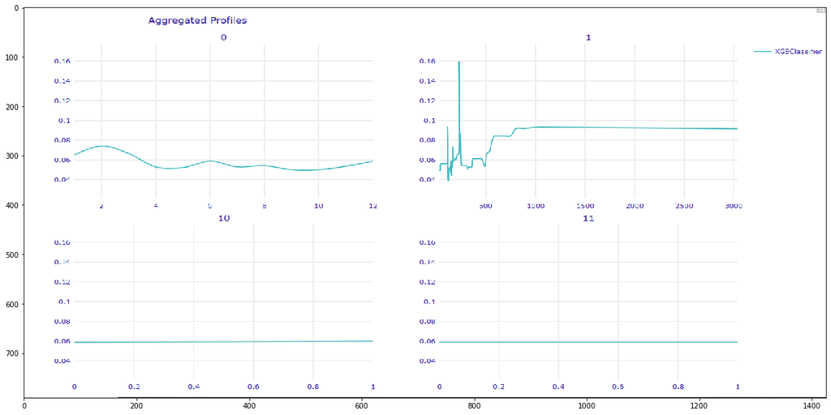

```python
plt.figure(figsize = (20,10))
image = mpimg.imread("pdp_xgboost.png")
plt.imshow(image,aspect='auto')
plt.show()
```

PDP. Widać, że wykresy dla zmiennych ciągłych mają nieregularny kształt - szczególnie dla zmiennej "1", czyli "history", która określa sumę pieniędzy wydaną przez konkretną osobę w ciągu ostatnich 12 miesięcy. Co ciekawe widać, że dla najmniejszych wartości zmiennej history (do około 100 dolarów) krzywa jest raczej pozioma tzn. niewrażliwa na zmienność tego parametru. Natomiast dla "history" o wartości około 112 dolarów następuje dziwny gwałtowny wzrost, a następnie spadek uplift. Dla kolejnych wartości zmiennej "history" obserwowane są fluktuacje. Kolejny silny wzrost jest obserwowany dla wartości około 228 dolarów, a następnie znaczny spadek wartości uplift jest dla wartości z przedziału 256-490 dolarów. Następnie obserwowany jest w miare stały wzrost uplift, chociaż schodkowy - dla wartości history od 490 USD do 805 USD. Natępnie krzywa praktycznie się stabilizuje. Efektem tak silnych fluktuacji w predykcji przy zmianach wartości zmiennej "history" może być fakt, że klasyfikator zapamiętuje wartości zmiennej "history" do przeuczania się.

Drugim wykresem, na którym widac jakąś szczególną zmienność jest ten dla zmiennej ciągłej "0", czyli "recency" - określa, ile miesięcy minęło od ostatnich zakupów danego klienta. Widać tutaj kilka ekstremów lokalnych, jednak funkcja ta jest raczej gładka. Widać trend malejący. Największy uplift jest generalnie dla klientów, którzy robili zakupy w ciągu ostatnich 3 miesięcy, czyli stosunkowo niedawno, co jest raczej intuicyjne. Później krzywa raczej się stabilizuje.

W przypadku pozostałych zmiennych, które są zmiennymi binarnymi, nie obserwujemy znacznego wpływu na predykcję (krzywe są prawie płaskie). Różnice w uplift wartości tych zmiennych są w granicach 0.01 lub 0.02, a niekiedy nie ma ich wcale (w pokazanych tutaj nie ma).

## **ALE DLA XGBOOST**

```python
ale_plot_uplift(r_xgb_model,X_train,Y_train,calc_uplift_filled)
```

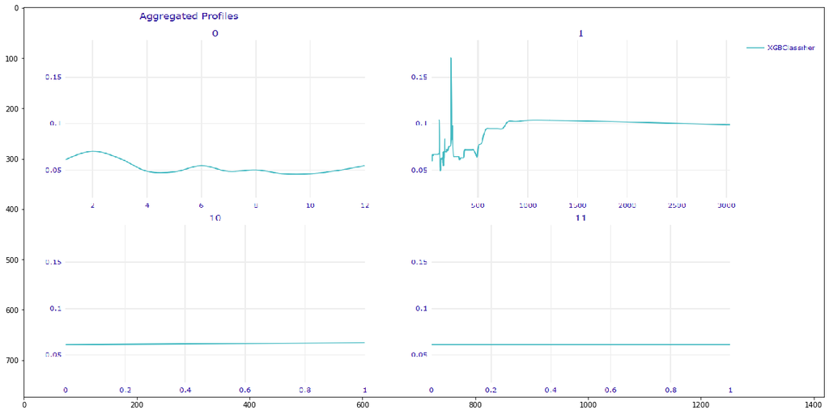

```python
plt.figure(figsize = (20,10))
image = mpimg.imread("ale_xgboost.png")
plt.imshow(image,aspect='auto')
plt.show()
```

Wykresy ALE dla wszystkich zmiennych są takie same jak PDP, co świadczy o tym, że w modelu nie ma interakcji.

## **PDP DLA SVM**

```python
pdp_plot_uplift(svm_model,X_train,Y_train,calc_uplift_filled)
```

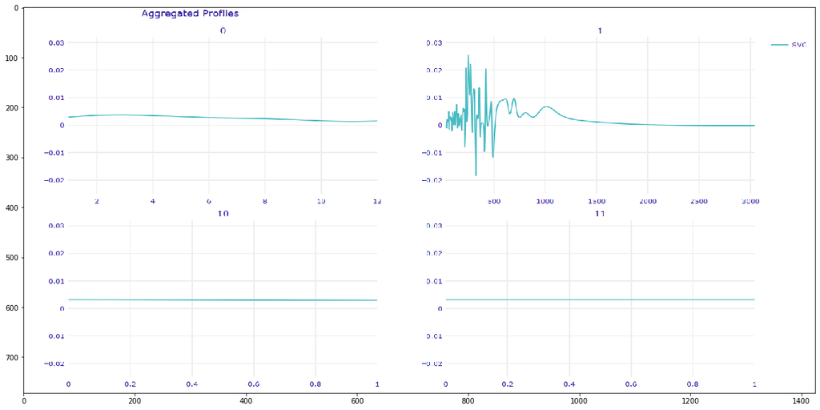

```python
plt.figure(figsize = (20,10))
image = mpimg.imread("pdp_svm.png")
plt.imshow(image,aspect='auto')
plt.show()
```

PDP. Widać, że w przypadku użycia modelu SVM zmienna "0" ("recency") nieco wypłaszczyła się, nie obserwujemy już ekstremów lokalnych na wykresie PDP tej zmiennej jak to było w przypadku użycia modelu XGBoost.

Jak widać, wykres PDP dla zmiennej "1" - "history" jest jeszcze bardziej zmienny niż w przypadku użycia modelu XGBoost, ale nie obserwujemy już tzw. "schodków". Te jeszcze silniejsze fluktuacje mogą wynikać z tego, że w SVM trochę oszukujemy, gdy pytamy go o prawdopodobieństwa - model ten tak naprawdę ich nie używa, tylko przypisuje klasę. Dodatkowo SVM ma jeszcze większy potencjał do przeuczania (co można tutaj zauważyć po bardzo wysokim wyniku modelu za zbiorze treningowym, a bardzo niskim na zbiorze walidacyjnym), wobec tego taka prosta ("schodek") może mu przechodzić przez wiele gęstych klas decyzyjnych.

W przypadku pozostałych zmiennych, które są zmiennymi binarnymi, nie obserwujemy żadnego wpływu na predykcję (krzywe pozostają płaskie).

## **ALE DLA SVM**

```python
ale_plot_uplift(svm_model,X_train,Y_train,calc_uplift_filled)
```

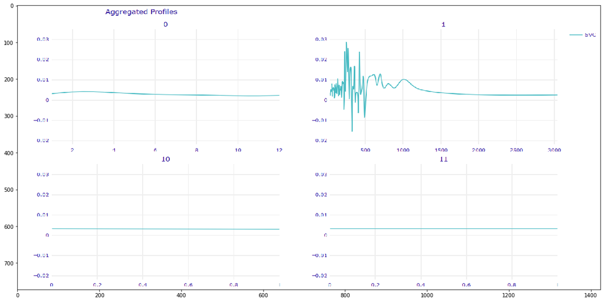

```python
plt.figure(figsize = (20,10))
image = mpimg.imread("ale_svm.png")
plt.imshow(image,aspect='auto')
plt.show()
```

Wykresy ALE dla wszystkich zmiennych są takie same jak PDP, co świadczy o tym, że w modelu nie ma interakcji.

## **PDP DLA REGRESJI LOGISTYCZNEJ**

```python
pdp_plot_uplift(lr_model,X_train,Y_train,calc_uplift_filled)
```

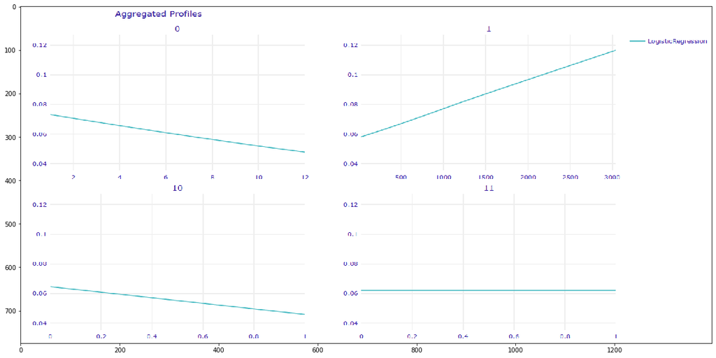

```python
plt.figure(figsize = (20,10))
image = mpimg.imread("pdp_lr.png")
plt.imshow(image,aspect='auto')
plt.show()
```

Wykresy PDP dla regresji logistycznej są liniowe, jednak w przypadku zmiennych binarnych nadal mało one wnoszą - aczkolwiek widoczny jest ich jakikolwiek wpływ na wartość upliftu (oprócz zmiennej "11" - "segment", która zgodnie z wynikami poprzedniej pracy domowej miała najniższy variable importance zarówno dla regresji logistycznej jak i modelu XGBoost).

W przypadku zmiennej "0" - "recency" jest to wykres liniowy o ujemnych współczynniku kierunkowym - można powiedzieć że podobny trend przedstawiał wykres PDP w przypadku XGBoosta.

W przypadku zmiennej "1" - "history" również można się dopatrzeć podobieństw między dwoma modelami - XGBoost a regresja logistyczna, tzn. wartość uplift w XGBoost miała znaczne skoki, ale ogólnie rzecz biorąc trend był rosący aż do wypłaszczenia wykresu, które utrzymywało się do najwyższej wartości "history", czyli wartości odstającej 3040 USD. Gdybyśmy spojrzeli na wykresy PDP obu modeli dla zmienniej "history", nie uwzględniając tej wartości odstającej, trend obu wykresów wydaje się być podobnie rosnący.

## **ALE DLA REGRESJI LOGISTYCZNEJ**

```python
ale_plot_uplift(lr_model,X_train,Y_train,calc_uplift_filled)
```

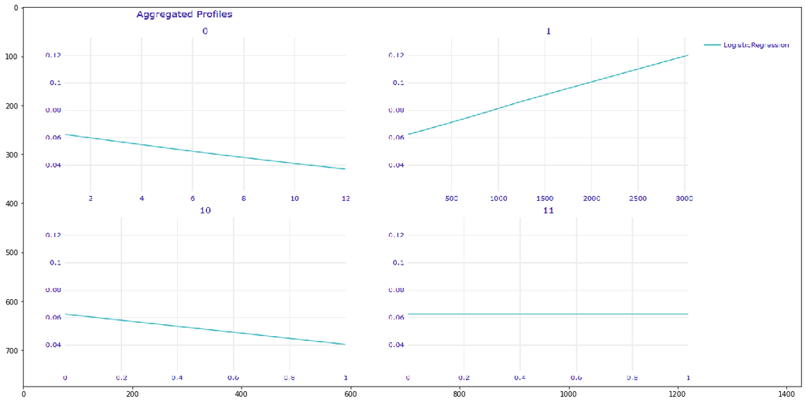

```python
plt.figure(figsize = (20,10))
image = mpimg.imread("ale_lr.png")
plt.imshow(image,aspect='auto')
plt.show()
```

Wykresy ALE dla wszystkich zmiennych są takie same jak PDP, co świadczy o tym, że w modelu nie ma interakcji.

# Załącznik

```python
from profiles import train, X_train, Y_train, X_valid, Y_valid, column_names, treatment_col
from model import train_xgb_model, train_logistic, evaluate_uplift, check_acc_diff, check_uplift_diff, local_search_xgb, local_search_svm,calc_uplift, predict_treatment
import pandas as pd
import dalex
import xgboost as xg
import numpy as np
import matplotlib.pyplot as plt
```

```python
import matplotlib.image as mpimg
```

```python
def calc_uplift_filled(model, x):
    treatment_col=11
    return predict_treatment(model, treatment_col, 1)(np.array(x)) - predict_treatment(model, treatment_col, 0)(np.array(x))

def pdp_plot_uplift(model,X_train,Y_train,predict_function):
    exp = dalex.Explainer(model, X_train,Y_train, predict_function)
    partial=exp.model_profile(type='partial')
    partial.plot()

def ale_plot_uplift(model,X_train,Y_train,predict_function):
    exp = dalex.Explainer(model, X_train,Y_train, predict_function)
    partial=exp.model_profile(type='accumulated')
    partial.plot()
```

## **MODEL** **XGBOOST**

```
best train uplift score = 0.0594653287098299
best valid uplift score = 0.03389569138409081
```

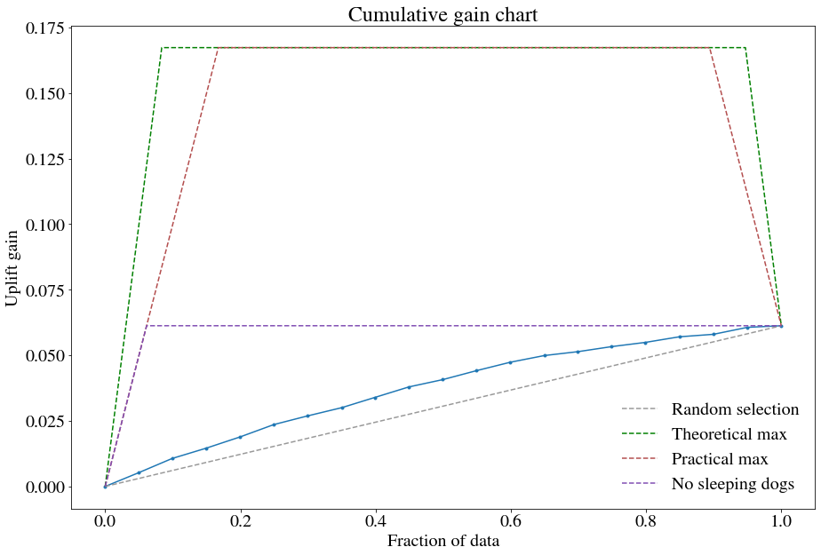

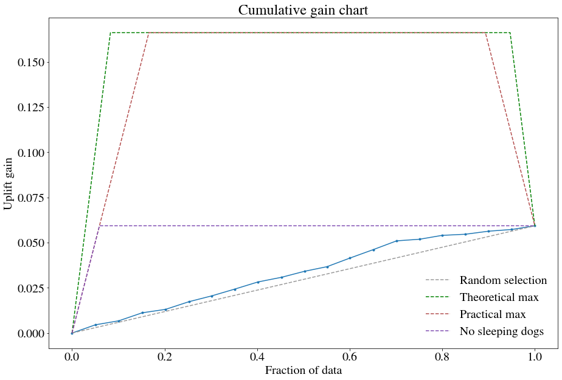

```python
r_xgb_model = local_search_xgb(X_train, Y_train, X_valid, Y_valid, treatment_col, just_get_model=True)
check_uplift_diff(r_xgb_model, "best", X_train, Y_train, X_valid, Y_valid, treatment_col)
```

## **MODEL** **SVM**

```python
svm_model = local_search_svm(X_train, Y_train, X_valid, Y_valid, treatment_col, just_get_model=True)
```

```
train score = 0.43358225819279694
valid score = 0.0014925833272794644
```

```
svm train uplift score = 0.43358225819279694
svm valid uplift score = 0.0014925833272794644
```

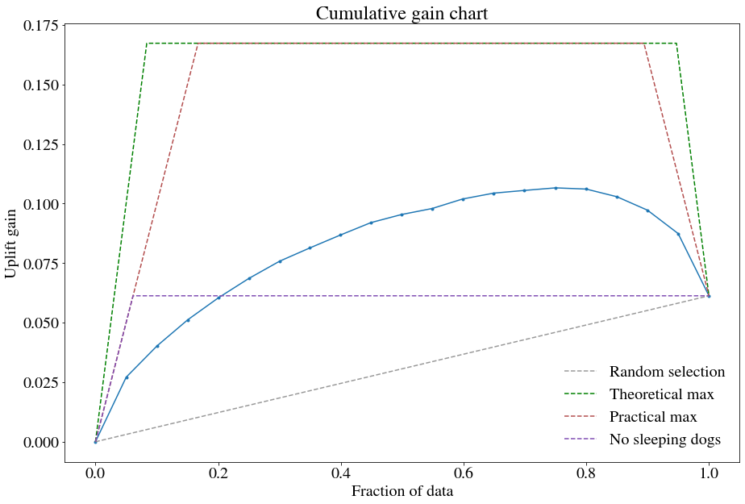

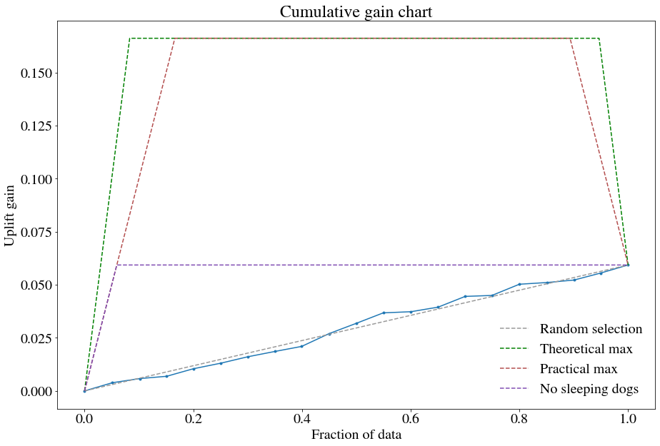

```python
check_uplift_diff(svm_model, "svm", X_train, Y_train, X_valid, Y_valid, treatment_col)
```

## **REGRESJA LOGISTYCZNA**

```
Logistic regression train score: 0.853203125
Logistic regression valid score: 0.85328125
logistic train uplift score = 0.01894758558321193
logistic valid uplift score = 0.02509077190747952
```

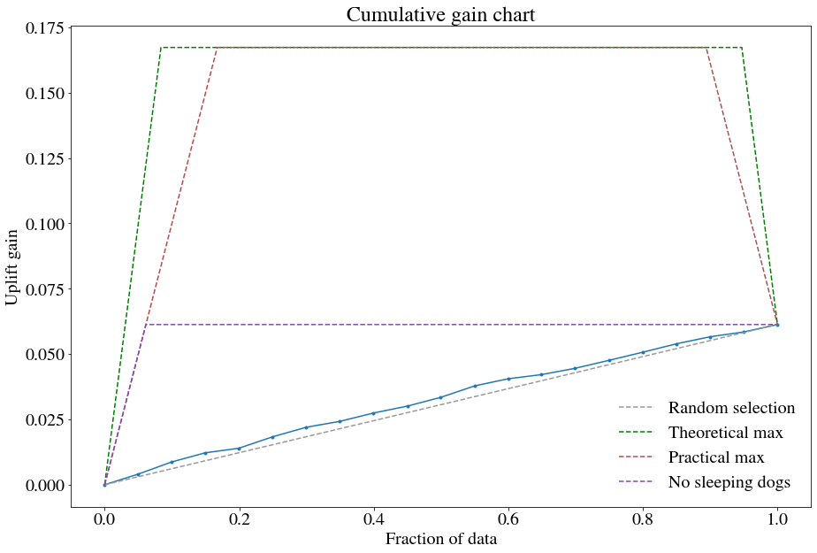

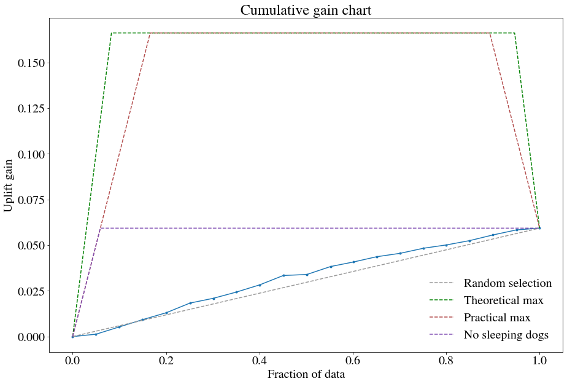

```python
lr_model = train_logistic(X_train, Y_train, X_valid, Y_valid, treatment_col)
check_uplift_diff(lr_model, "logistic", X_train, Y_train, X_valid, Y_valid, treatment_col)
```